# Analysis of United States Tornado Data

**Kiyoshi Amano 5/11/2022**

# Introduction

The violently rotating column of air known as a tornado has the potential to wreak a devastating amount of damage. While many of the deadliest recorded tornadoes within the United States (US) occurred in the 19th and 20th centuries, and advances in tracking and infrastructure have made us less susceptible to tornadoes, the threat still lingers. A 2011 tornado in Joplin, Missouri is the seventh deadliest recorded US tornado, taking the lives of 158 people.

The media commonly uses the term "Tornado Alley" for the area in the central US where tornadoes most frequently occur. While it is loosely defined, it generally refers to parts of states including Texas, Oklahoma, Kansas, Nebraska, Iowa, South Dakota, Minnesota, Wisconsin, Illinois, Indiana, Missouri, Arkansas, North Dakota, Montana, and Ohio. While most people have heard of this term, most people have never heard of "Dixie Alley," which refers to an area in the southern US that is also especially vulnerable to tornadoes. Geographical analysis of tornadoes in recent years has suggested that the region where tornadoes tend to originate is shifting towards the southeast as climate conditions change.

In order to better understand tornado trends in the US over time, this tutorial analyzes US tornado data to compare the Tornado Alley, Dixie Alley, and outside regions to determine how susceptible each area is to the threat of tornadoes. This analysis aims to bring awareness to the damage caused by tornadoes in the southern US in order to change media perception of what areas are at risk for tornadoes and inform policy decisions about where improvements to infrastructure are needed to better protect people from tornadoes.

# Data Collection

The data used in this analysis comes from the National Oceanic and Atmospheric Administration's Storm Prediction Center. The dataset can be found downloadable as a CSV file at the bottom of this page: https://www.spc.noaa.gov/wcm/. It includes data for all recorded US tornadoes from 1950 to 2020, with information regarding the time and date, area, severity, injuries and fatalaties, and property damage. For this analysis, the focus will be on the dates tornadoes occurred, the latitude and longitude at which they originated, the number of deaths, and the property damage in dollars. More information about what exactly is recorded can be found here: https://www.spc.noaa.gov/wcm/data/SPC_severe_database_description.pdf.

```python
# Importing necessary packages
import numpy as np
import pandas as pd
import matplotlib.pyplot as plt
import datetime as dt
import warnings
from IPython import display
from statsmodels.formula.api import ols

warnings.filterwarnings('ignore')
%matplotlib inline

# Using pandas to read the datafile into a dataframe
tornadoes = pd.read_csv("1950-2020_all_tornadoes.csv")

# Displaying the first 10 rows of the dataframe
tornadoes.head(10)
```

|  | om | yr | mo | dy | date | time | tz | st | stf | stn | ... | len | wid | ns | sn | sg | f1 | f2 | f3 | f4 | fc |
| --- | --- | --- | --- | --- | --- | --- | --- | --- | --- | --- | --- | --- | --- | --- | --- | --- | --- | --- | --- | --- | --- |
| 0 | 192 | 1950 | 10 | 1 | 1950-10-01 | 21:00:00 | 3 | OK | 40 | 23 | ... | 15.8 | 10 | 1 | 1 | 1 | 25 | 0 | 0 | 0 | 0 |
| 1 | 193 | 1950 | 10 | 9 | 1950-10-09 | 02:15:00 | 3 | NC | 37 | 9 | ... | 2.0 | 880 | 1 | 1 | 1 | 47 | 0 | 0 | 0 | 0 |
| 2 | 195 | 1950 | 11 | 20 | 1950-11-20 | 02:20:00 | 3 | KY | 21 | 1 | ... | 0.1 | 10 | 1 | 1 | 1 | 177 | 0 | 0 | 0 | 0 |
| 3 | 196 | 1950 | 11 | 20 | 1950-11-20 | 04:00:00 | 3 | KY | 21 | 2 | ... | 0.1 | 10 | 1 | 1 | 1 | 209 | 0 | 0 | 0 | 0 |
| 4 | 197 | 1950 | 11 | 20 | 1950-11-20 | 07:30:00 | 3 | MS | 28 | 14 | ... | 2.0 | 37 | 1 | 1 | 1 | 101 | 0 | 0 | 0 | 0 |
| 5 | 194 | 1950 | 11 | 4 | 1950-11-04 | 17:00:00 | 3 | PA | 42 | 5 | ... | 15.9 | 100 | 1 | 1 | 1 | 71 | 11 | 0 | 0 | 0 |
| 6 | 198 | 1950 | 12 | 2 | 1950-12-02 | 15:00:00 | 3 | IL | 17 | 7 | ... | 18.8 | 50 | 1 | 1 | 1 | 119 | 117 | 0 | 0 | 0 |
| 7 | 199 | 1950 | 12 | 2 | 1950-12-02 | 16:00:00 | 3 | IL | 17 | 8 | ... | 18.0 | 200 | 1 | 1 | 1 | 119 | 5 | 0 | 0 | 0 |
| 8 | 200 | 1950 | 12 | 2 | 1950-12-02 | 16:25:00 | 3 | AR | 5 | 12 | ... | 7.8 | 10 | 1 | 1 | 1 | 65 | 0 | 0 | 0 | 0 |
| 9 | 201 | 1950 | 12 | 2 | 1950-12-02 | 17:30:00 | 3 | IL | 17 | 9 | ... | 9.6 | 50 | 1 | 1 | 1 | 157 | 0 | 0 | 0 | 0 |

10 rows × 29 columns

# Data Processing

The data is already in a relatively clean format, so little processing is necessary to reach the desired state. In order to adjust the table to suit our needs, we will ensure that any tornadoes without recorded starting latitude and longitude data are removed as their locations cannot be clearly plotted, and columns unneeded for our data analysis will be removed to ensure that relevant parts can be viewed more clearly. In addition, kept columns will be renamed to be more easily understood.

```python
# Ensuring tornadoes without starting recorded coordinates are removed from the dataset
tornadoes = tornadoes.dropna(how = "any", subset = ["slat", "slon"])

# Removing unneeded columns
tornadoes = tornadoes.drop(["om", "mo", "dy", "tz", "stf", "stn", "inj", "closs", "mag", "elat", "elon", "len", "wid", "ns", "sn", "sg", "f1", "f2", "f3", "f4", "fc"], axis = 1)

# Renaming columns
tornadoes.columns = ["Year", "Date", "Time", "State", "Fatalities", "Loss", "StartLat", "StartLon"]

# Displaying the first 10 rows of the updated dataframe
tornadoes.head(10)
```

|  | Year | Date | Time | State | Fatalities | Loss | StartLat | StartLon |
| --- | --- | --- | --- | --- | --- | --- | --- | --- |
| 0 | 1950 | 1950-10-01 | 21:00:00 | OK | 0 | 4.0 | 36.73 | -102.52 |
| 1 | 1950 | 1950-10-09 | 02:15:00 | NC | 0 | 5.0 | 34.17 | -78.60 |
| 2 | 1950 | 1950-11-20 | 02:20:00 | KY | 0 | 5.0 | 37.37 | -87.20 |
| 3 | 1950 | 1950-11-20 | 04:00:00 | KY | 0 | 5.0 | 38.20 | -84.50 |
| 4 | 1950 | 1950-11-20 | 07:30:00 | MS | 0 | 4.0 | 32.42 | -89.13 |
| 5 | 1950 | 1950-11-04 | 17:00:00 | PA | 0 | 5.0 | 40.20 | -76.12 |
| 6 | 1950 | 1950-12-02 | 15:00:00 | IL | 1 | 4.0 | 38.97 | -90.05 |
| 7 | 1950 | 1950-12-02 | 16:00:00 | IL | 2 | 6.0 | 38.75 | -89.67 |
| 8 | 1950 | 1950-12-02 | 16:25:00 | AR | 0 | 1.0 | 36.12 | -91.83 |
| 9 | 1950 | 1950-12-02 | 17:30:00 | IL | 0 | 4.0 | 38.17 | -89.78 |

# Visualizing US Tornado Data

Using the Google Maps API, the coordinates of recorded tornadoes from 1950-2020 can be plotted to create a heatmap showing where tornadoes are most concentrated. This will provide a visualization of whether Tornado Alley accurately reflects the areas where tornadoes are most frequent. In order to use the Google Maps API a personal Google Maps Javascript API key is needed, which can be obtained by following the steps at https://developers.google.com/maps/documentation/javascript/get-api-key.

```python
# Terminal commands allowing for installation and usage of the Google Maps API in Jupyter
!jupyter nbextension enable --py --sys-prefix widgetsnbextension
!pip install gmaps
!jupyter nbextension enable --py --sys-prefix gmaps

# Importing necessary packages for use of the Google Maps API
import gmaps
import gmaps.datasets
```

[figure not shown]

```python
# Inputting the API key
gmaps.configure(api_key = "AIzaSyBXmZAxitqrROlEsJSjlpJZwBVZLLCw87Q")

# Plotting coordinates from tornado data onto heatmap
tornado_layer = gmaps.heatmap_layer(tornadoes[["StartLat", "StartLon"]])
fig = gmaps.figure(map_type = "HYBRID")
fig.add_layer(tornado_layer)

# Displaying the figure created after downloading it
display.Image("heatmap.png")
```

# Observations

Increasing concentration of tornadoes is displayed by green areas that become warmer until becoming red for the areas where tornadoes are most concentrated. The map does show high concentration in the Tornado Alley region of the central US. However, dark red areas are also present throughout the Dixie Alley region of the southern US. The threat of tornadoes in this region may be just as severe as Tornado Alley, or at least distinctly more severe than the rest of the US outside of the Alleys.

# Number of Tornadoes over Time

Tornadoes will be divided into Tornado Alley, Dixie Alley, and neither categories and the number of tornadoes each year will be plotted over time. A regression line is added to allow for clearer visualization of trends for tornado occurrences in each region.

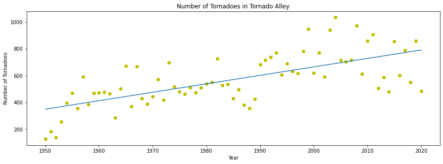

```
Tornado Alley Slope and Y-intercept: [ 6.31549296e+00 -1.19655775e+04]
```

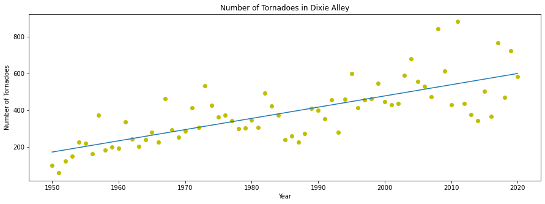

```
Dixie Alley Slope and Y-intercept: [ 6.11542589e+00 -1.17536556e+04]
```

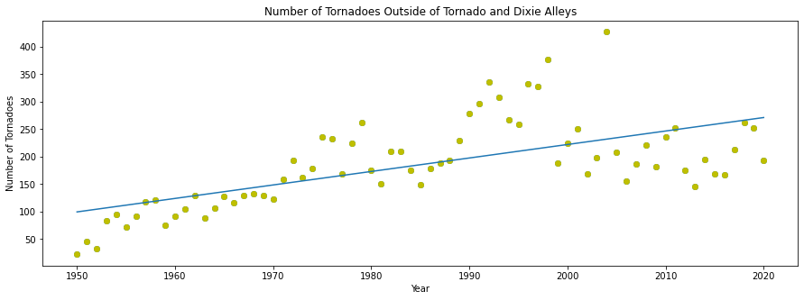

```
Outside Region Slope and Y-intercept: [ 2.45264923e+00 -4.68324111e+03]
```

```python
# Creating a list of the years from 1950 to 2020 to serve as the x-values for the plot
years = [*range(1950, 2021)]

# Creating a dataframe containing only tornadoes that occurred in Tornado Alley states
tornado_alley = tornadoes[tornadoes["State"].str.startswith(("TX", "MO", "AR", "OK", "KS", "NE", "IA", "SD", "MN", "WI", "IL", "IN", "ND", "MT", "OH"))]

# Creating a list containing the number of tornadoes for each year to serve as y-values for the plot
tornado_count = tornado_alley.groupby("Year").size().tolist()

# Adjusting the figure size to be bigger
plt.figure(figsize = (15, 5))

# Calculating coefficients for regression and creating linear regression to plot
coefficients = np.polyfit(x = years, y = tornado_count, deg = 1)
line = np.poly1d(coefficients)

# Plotting x-values, y-values, and regression line
plt.plot(years, tornado_count, "yo", years, line(years))

# Setting labels for plot
plt.title("Number of Tornadoes in Tornado Alley")
plt.xlabel("Year")
plt.ylabel("Number of Tornadoes")

# Displaying final plot
plt.show()

# Printing coefficients for calculated regression line
print("Tornado Alley Slope and Y-intercept: " + str(coefficients))


# Using the same process to create plot for Dixie Alley states
dixie_alley = tornadoes[tornadoes["State"].str.startswith(("TX", "AR", "LA", "MS", "TN", "AL", "GA", "KY", "SC", "NC", "MO"))]
dixie_count = dixie_alley.groupby("Year").size().tolist()
plt.figure(figsize = (15, 5))
coefficients = np.polyfit(x = years, y = dixie_count, deg = 1)
line = np.poly1d(coefficients)
plt.plot(years, dixie_count, "yo", years, line(years))
plt.title("Number of Tornadoes in Dixie Alley")
plt.xlabel("Year")
plt.ylabel("Number of Tornadoes")
plt.show()

print("Dixie Alley Slope and Y-intercept: " + str(coefficients))

# Using the same process to create plot for states not in Tornado Alley or Dixie Alley
neither = tornadoes[~tornadoes["State"].str.startswith(("TX", "OK", "KS", "NE", "IA", "SD", "MN", "WI", "IL", "IN", "MO", "AR", "ND", "MT", "OH", "LA", "MS", "TN", "AL", "GA", "KY", "SC", "NC"))]
neither_count = neither.groupby("Year").size().tolist()
plt.figure(figsize = (15, 5))
coefficients = np.polyfit(x = years, y = neither_count, deg = 1)
line = np.poly1d(coefficients)
plt.plot(years, neither_count, "yo", years, line(years))
plt.scatter(years, neither_count)
plt.title("Number of Tornadoes Outside of Tornado and Dixie Alleys")
plt.xlabel("Year")
plt.ylabel("Number of Tornadoes")
plt.show()

print("Outside Region Slope and Y-intercept: " + str(coefficients))
```

# Exploratory Data Analysis

Based off the graphs and calculated regression lines for tornadoes in each region, it's clear that there are regional differences in the number of tornadoes over time. The overall number of tornadoes in Tornado Alley and Dixie Alley states are much higher than the number of tornadoes in all states outside these areas. However, the slopes of the lines for Tornado Alley and Dixie Alley are very similar, being 6.32 and 6.12 respectively, differing much more than the slope for the linear regression of tornadoes outside. Numbers of tornadoes recorded may also be affected by improvements in ability to track and record tornadoes since data first started being collected in 1950 which may contribute to the positive slope of all lines. However, the number of tornadoes in Tornado Alley and Dixie Alley in particular are increasing at a much faster rate than outside these areas.

# Hypothesis Testing for Regional Differences in Number of Tornadoes over Time

The null hypothesis to test validity of will be that the region does not affect the number of tornadoes. Using the statsmodels linear regression functionality, an interaction variable will be added to calculate linear regression for each region's tornado count over time and calculate associated p-values to be displayed.

```python
# Since Arkansas, Missouri, and Texas overlap between Dixie Alley and Tornado Alley, in order to provide clear classification
# of each recorded tornado, only states exclusive to each region are included in the classifications for Dixie Alley and
# Tornado Alley.

# This function returns a string classification depending on the state associated with a region
def classify(row):
    if row["State"].startswith(("OK", "KS", "NE", "IA", "SD", "MN", "WI", "IL", "IN", "ND", "MT", "OH")):
        return "Tornado"
    elif row["State"].startswith(("LA", "MS", "TN", "AL", "GA", "KY", "SC", "NC")):
        return "Dixie"
    elif row["State"].startswith(("TX", "MO", "AR")):
        return "Both"
    return "Neither"

# Creating a new column for region, with the values depending on the classification function's output for each row
tornadoes["Region"] = tornadoes.apply(lambda row: classify(row), axis = 1)

# Creating dataframe with year, region, and total number of tornadoes
region_counts = tornadoes.groupby(["Region", "Year"]).size().to_frame().reset_index()
region_counts.columns = ["Region", "Year", "Count"]

# Displaying the first 10 rows of the dataframe
print(region_counts.head(10))

# Calculating linear regression function for each region
regression_model = ols(formula = "Count ~ Year * Region", data = region_counts).fit()
print(regression_model.summary())

# Calculating slope for each region based off output
slope_both = regression_model.params[4]
slope_dixie = slope_both + regression_model.params[5]
slope_tornado = slope_both + regression_model.params[7]
slope_neither = slope_both + regression_model.params[6]

# Printing slope for each region
print("Dixie Alley Slope: " + str(slope_dixie))
print("Tornado Alley Slope: " + str(slope_tornado))
print("Outside Region Slope: " + str(slope_neither))
```

```
  Region  Year  Count
0   Both  1950     39
1   Both  1951     24
2   Both  1952     48
3   Both  1953     48
4   Both  1954    144
5   Both  1955    158
6   Both  1956     93
7   Both  1957    214
8   Both  1958    112
9   Both  1959    129
                            OLS Regression Results
==============================================================================
Dep. Variable:                  Count   R-squared:                       0.667
Model:                            OLS   Adj. R-squared:                  0.658
Method:                 Least Squares   F-statistic:                     78.86
Date:                Thu, 12 May 2022   Prob (F-statistic):           3.65e-62
Time:                        04:53:43   Log-Likelihood:                -1637.1
No. Observations:                 284   AIC:                             3290.
Df Residuals:                     276   BIC:                             3319.
Df Model:                           7
Covariance Type:            nonrobust
==========================================================================================
                             coef    std err          t      P>|t|      [0.025      0.975]
------------------------------------------------------------------------------------------
Intercept              -3297.9463    899.344     -3.667      0.000   -5068.391   -1527.502
Region[T.Dixie]        -5157.7629   1271.864     -4.055      0.000   -7661.550   -2653.976
Region[T.Neither]      -1385.2948   1271.864     -1.089      0.277   -3889.082    1118.492
Region[T.Tornado]      -5369.6848   1271.864     -4.222      0.000   -7873.472   -2865.898
Year                       1.7575      0.453      3.879      0.000       0.866       2.649
Year:Region[T.Dixie]       2.6005      0.641      4.059      0.000       1.339       3.862
Year:Region[T.Neither]     0.6952      0.641      1.085      0.279      -0.566       1.956
Year:Region[T.Tornado]     2.8005      0.641      4.371      0.000       1.539       4.062
==============================================================================
Omnibus:                       31.724   Durbin-Watson:                   1.576
Prob(Omnibus):                  0.000   Jarque-Bera (JB):               45.741
Skew:                           0.722   Prob(JB):                     1.17e-10
Kurtosis:                       4.333   Cond. No.                     9.21e+05
==============================================================================

Notes:
[1] Standard Errors assume that the covariance matrix of the errors is correctly specified.
[2] The condition number is large, 9.21e+05. This might indicate that there are
strong multicollinearity or other numerical problems.
Dixie Alley Slope: 4.357947686131453
Tornado Alley Slope: 4.55801475519565
Outside Region Slope: 2.4526492287183306
```

# Hypothesis Testing Results

As seen by the p-values of 0.000 displayed under the P>|t| column for linear regression coefficients, the calculated linear regressions for states exclusive in Dixie Alley and Tornado Alley are statistically significant. The null hypothesis can be rejected so the number of tornadoes is affected by the regions as classified here. In addition, the slopes for the regression lines for Dixie Alley and Tornado Alley differ by just 4.4843%, whereas they differ from regions outside both by 56.094% and 60.1997% respectively. The trends in increasing numbers of tornadoes for Dixie Alley and Tornado Alley are very similar.

# Investigating Trends in Number of Deaths

While the overall number of tornadoes is highest in Tornado Alley, Dixie Alley may be more severely affected. According to Dr. Harold Brooks, the senior research scientist at the National Oceanic and Atmospheric Administration, southeastern states are the most vulnerable due to increased poverty conditions as well as lower level of infrastructure, with many living in manufactured homes. It's time to investigate how the number of deaths resulting from tornadoes differs in each region. The null hypothesis will be that region has no impact on the number of deaths caused by tornadoes.

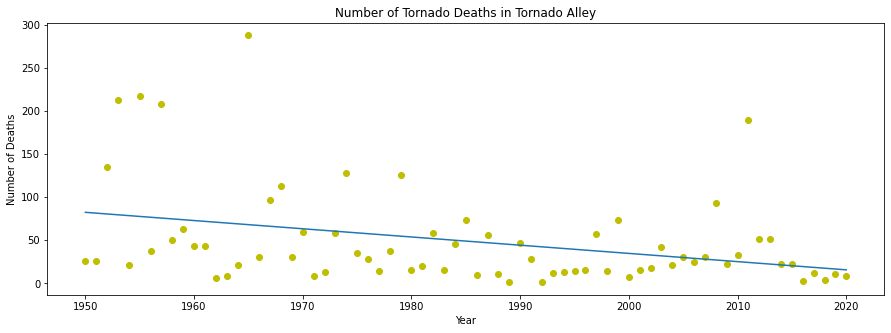

```
Tornado Alley Slope and Y-intercept: [-9.54359490e-01  1.94344584e+03]
```

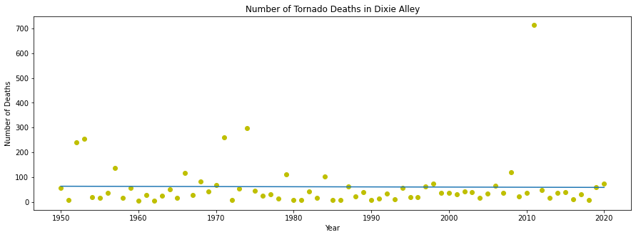

```
Dixie Alley Slope and Y-intercept: [-6.83769282e-02  1.96981724e+02]
```

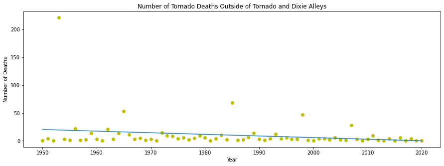

```
Outside Region Slope and Y-intercept: [-2.89771965e-01  5.85310027e+02]
```

```python
# Using the same process for creating plots showing number of tornadoes in each region to create plots for deaths over time

# Creating plot for number of deaths over time in Tornado Alley states
tornado_deaths = tornado_alley.groupby("Year")["Fatalities"].sum().tolist()
plt.figure(figsize = (15, 5))
coefficients = np.polyfit(x = years, y = tornado_deaths, deg = 1)
line = np.poly1d(coefficients)
plt.plot(years, tornado_deaths, "yo", years, line(years))
plt.title("Number of Tornado Deaths in Tornado Alley")
plt.xlabel("Year")
plt.ylabel("Number of Deaths")
plt.show()

print("Tornado Alley Slope and Y-intercept: " + str(coefficients))

# Creating plot for number of deaths over time in Dixie Alley states
dixie_deaths = dixie_alley.groupby("Year")["Fatalities"].sum().tolist()
plt.figure(figsize = (15, 5))
coefficients = np.polyfit(x = years, y = dixie_deaths, deg = 1)
line = np.poly1d(coefficients)
plt.plot(years, dixie_deaths, "yo", years, line(years))
plt.title("Number of Tornado Deaths in Dixie Alley")
plt.xlabel("Year")
plt.ylabel("Number of Deaths")
plt.show()

print("Dixie Alley Slope and Y-intercept: " + str(coefficients))

# Creating plot for number of deaths over time in states outside of Tornado Alley and Dixie Alley
neither_deaths = neither.groupby("Year")["Fatalities"].sum().tolist()
plt.figure(figsize = (15, 5))
coefficients = np.polyfit(x = years, y = neither_deaths, deg = 1)
line = np.poly1d(coefficients)
plt.plot(years, neither_deaths, "yo", years, line(years))
plt.title("Number of Tornado Deaths Outside of Tornado and Dixie Alleys")
plt.xlabel("Year")
plt.ylabel("Number of Deaths")
plt.show()

print("Outside Region Slope and Y-intercept: " + str(coefficients))
```

# Exploratory Data Analysis

As seen by the linear regressions for the number of deaths in each region, there is a clearly visible downward trend in the number of deaths for Tornado Alley states and states outside. As seen by the slopes, all are facing a downward trend in the number of deaths, but the slope for Tornado Deaths in Dixie Alley states is much lower than those outside. The number of deaths in this region is decreasing at a much slower rate. This could be due to relatively lower improvements to infrastructure in this region compared to areas outside.

# Hypothesis Testing for Regional Differences in Number of Deaths over Time

The null hypothesis to test validity of will be that the region does not affect the number of deaths. Using the statsmodels linear regression functionality, an interaction variable will be added to calculate linear regression for each region's death count over time and calculate associated p-values to be displayed.

```python
# Creating dataframe with year, region, and total number of deaths
region_deaths = tornadoes.groupby(["Region", "Year"])["Fatalities"].sum().to_frame().reset_index()
region_deaths.columns = ["Region", "Year", "Deaths"]

# Displaying the first 10 rows of the dataframe
print(region_deaths.head(10))

# Calculating linear regression function for each region
regression_model = ols(formula = "Deaths ~ Year * Region", data = region_deaths).fit()
print(regression_model.summary())

# Calculating slope for each region based off output
slope_both = regression_model.params[4]
slope_dixie = slope_both + regression_model.params[5]
slope_tornado = slope_both + regression_model.params[7]
slope_neither = slope_both + regression_model.params[6]

# Printing slope for each region
print("Dixie: " + str(slope_dixie))
print("Tornado: " + str(slope_tornado))
print("Neither: " + str(slope_neither))
```

```
  Region  Year  Deaths
0   Both  1950      13
1   Both  1951       3
2   Both  1952     130
3   Both  1953     150
4   Both  1954       6
5   Both  1955       6
6   Both  1956       7
7   Both  1957      97
8   Both  1958       3
9   Both  1959      52
                            OLS Regression Results
==============================================================================
Dep. Variable:                 Deaths   R-squared:                       0.073
Model:                            OLS   Adj. R-squared:                  0.050
Method:                 Least Squares   F-statistic:                     3.127
Date:                Thu, 12 May 2022   Prob (F-statistic):            0.00342
Time:                        04:53:43   Log-Likelihood:                -1507.8
No. Observations:                 284   AIC:                             3032.
Df Residuals:                     276   BIC:                             3061.
Df Model:                           7
Covariance Type:            nonrobust
==========================================================================================
                             coef    std err          t      P>|t|      [0.025      0.975]
------------------------------------------------------------------------------------------
Intercept                577.5832    570.530      1.012      0.312    -545.561    1700.727
Region[T.Dixie]         -958.1846    806.852     -1.188      0.236   -2546.550     630.181
Region[T.Neither]          7.7269    806.852      0.010      0.992   -1580.639    1596.093
Region[T.Tornado]        788.2795    806.852      0.977      0.329    -800.086    2376.645
Year                      -0.2804      0.287     -0.976      0.330      -0.846       0.285
Year:Region[T.Dixie]       0.4925      0.406      1.212      0.227      -0.308       1.293
Year:Region[T.Neither]    -0.0094      0.406     -0.023      0.982      -0.809       0.791
Year:Region[T.Tornado]    -0.3935      0.406     -0.968      0.334      -1.194       0.407
==============================================================================
Omnibus:                      350.378   Durbin-Watson:                   2.090
Prob(Omnibus):                  0.000   Jarque-Bera (JB):            22856.532
Skew:                           5.516   Prob(JB):                         0.00
Kurtosis:                      45.542   Cond. No.                     9.21e+05
==============================================================================

Notes:
[1] Standard Errors assume that the covariance matrix of the errors is correctly specified.
[2] The condition number is large, 9.21e+05. This might indicate that there are
strong multicollinearity or other numerical problems.
Dixie: 0.2120389000667135
Tornado: -0.6739436619675634
Neither: -0.28977196512853887
```

# Hypothesis Testing Results

As seen by the p-values that are greater than the significance value of 0.05 displayed under the P>|t| column for linear regression coefficients, the calculated linear regressions for states exclusive in Dixie Alley and Tornado Alley are not statistically significant. The null hypothesis cannot be rejected so the number of deaths is not affected by the regions as classified here. However, it's interesting to note the slopes calculated by the linear regression for states exclusive in Dixie Allie, Tornado Alley, and those in neither. The slope for the number of deaths in states exclusive to Dixie Alley is actually positive. This means that the negative slope found by the regression for the graphs (which included states in both Dixie Alley and Tornado Alley) was due to the inclusion of these states. When you look at Dixie Alley exclusive states, the number of deaths from tornadoes is actually not decreasing, unlike for Tornado Alley exclusive states and those outside.

# Investigating Trends in Property Damage

Since Dixie Alley has relatively lower levels of infrastructure, it's important to see whether tornadoes there are causing more severe property damage than outside the region. The null hypothesis to investigate validity of will be that region has no impact on the property damage caused by tornadoes.

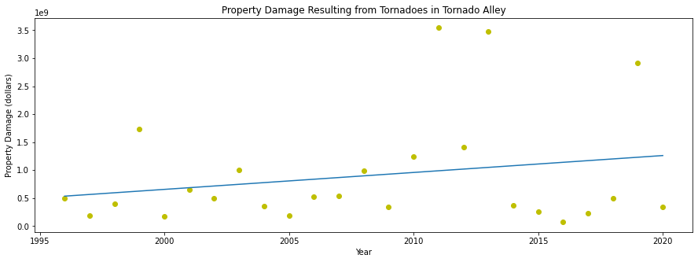

```
Tornado Alley Slope and Y-intercept: [ 3.02465101e+07 -5.98374449e+10]
```

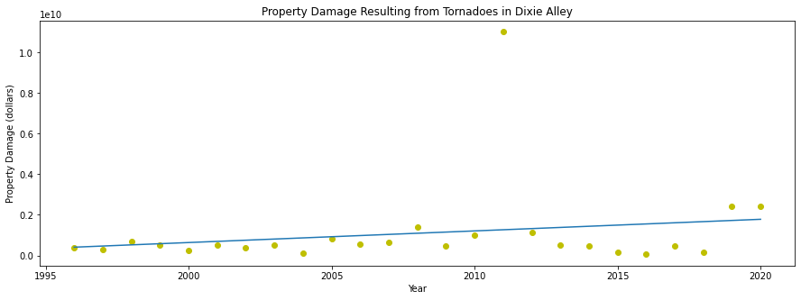

```
Dixie Alley Slope and Y-intercept: [ 5.72963237e+07 -1.13958164e+11]
```

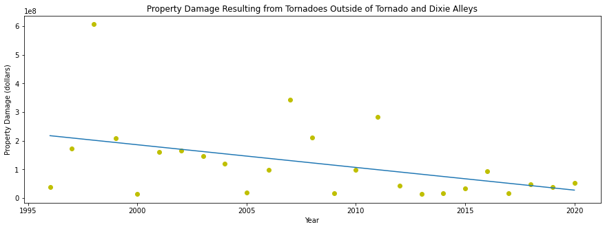

```
Outside Region Slope and Y-intercept: [-7.90965823e+06  1.60056574e+10]
```

```python
# Single value dollar amount estimates for tornadoes only started in 1996 for this dataset.
# However, from 1996 to 2015 these values are represented in millions of dollars, whereas from
# 2016 to 2020 these values are represented by whole dollar numbers. In order to create a single column
# that has a unified format, dataframes are divided and a new column is calculated for both which is then combined.

# Creating dataframes for tornadoes with property damage recorded in millions of dollars
tornado_alley_first = tornado_alley[(tornado_alley["Year"] > 1995) & (tornado_alley["Year"] < 2016)]
dixie_alley_first = dixie_alley[(dixie_alley["Year"] > 1995) & (dixie_alley["Year"] < 2016)]
neither_first = neither[(neither["Year"] > 1995) & (neither["Year"] < 2016)]

# Creating dataframes for tornadoes with property damage recorded in whole dollar values
tornado_alley_second = tornado_alley[tornado_alley["Year"] > 2015]
dixie_alley_second = dixie_alley[dixie_alley["Year"] > 2015]
neither_second = neither[neither["Year"] > 2015]

# Creating new column for property damage with whole dollar values
tornado_alley_first["PropDmg"] = tornado_alley_first["Loss"] * 1000000
dixie_alley_first["PropDmg"] = dixie_alley_first["Loss"] * 1000000
neither_first["PropDmg"] = neither_first["Loss"] * 1000000

# Creating new column for property damage that reflects the whole dollar values already recorded
tornado_alley_second["PropDmg"] = tornado_alley_second["Loss"]
dixie_alley_second["PropDmg"] = dixie_alley_second["Loss"]
neither_second["PropDmg"] = neither_second["Loss"]

# Combining the two dataframes to create unified dataframe with property damage for each region
tornado_alley_damage = pd.concat([tornado_alley_first, tornado_alley_second])
dixie_alley_damage = pd.concat([dixie_alley_first, dixie_alley_second])
neither_damage = pd.concat([neither_first, neither_second])

# Using the same process for creating plots showing number of tornadoes in each region to create plots for property damage over time

# Creating a list of the years from 1996 to 2020 to serve as the x-values for the plot
years = [*range(1996, 2021)]

# Creating plot for property daamge over time in Tornado Alley states
tornado_dmg = tornado_alley_damage.groupby("Year")["PropDmg"].sum().tolist()
plt.figure(figsize = (15, 5))
coefficients = np.polyfit(x = years, y = tornado_dmg, deg = 1)
line = np.poly1d(coefficients)
plt.plot(years, tornado_dmg, "yo", years, line(years))
plt.title("Property Damage Resulting from Tornadoes in Tornado Alley")
plt.xlabel("Year")
plt.ylabel("Property Damage (dollars)")
plt.show()

print("Tornado Alley Slope and Y-intercept: " + str(coefficients))

# Creating plot for property damage over time in Dixie Alley states
dixie_dmg = dixie_alley_damage.groupby("Year")["PropDmg"].sum().tolist()
plt.figure(figsize = (15, 5))
coefficients = np.polyfit(x = years, y = dixie_dmg, deg = 1)
line = np.poly1d(coefficients)
plt.plot(years, dixie_dmg, "yo", years, line(years))
plt.title("Property Damage Resulting from Tornadoes in Dixie Alley")
plt.xlabel("Year")
plt.ylabel("Property Damage (dollars)")
plt.show()

print("Dixie Alley Slope and Y-intercept: " + str(coefficients))

# Creating plot for property damage over time in states outside of Tornado Alley and Dixie Alley
neither_dmg = neither_damage.groupby("Year")["PropDmg"].sum().tolist()
plt.figure(figsize = (15, 5))
coefficients = np.polyfit(x = years, y = neither_dmg, deg = 1)
line = np.poly1d(coefficients)
plt.plot(years, neither_dmg, "yo", years, line(years))
plt.title("Property Damage Resulting from Tornadoes Outside of Tornado and Dixie Alleys")
plt.xlabel("Year")
plt.ylabel("Property Damage (dollars)")
plt.show()

print("Outside Region Slope and Y-intercept: " + str(coefficients))
```

```python
# Filtering dataframes to include only states exclusive to Tornado Alley and Dixie Alley for clear regional classification
tornado_alley_damage_exclusive = tornado_alley_damage[tornado_alley_damage["State"].str.startswith(("OK", "KS", "NE", "IA", "SD", "MN", "WI", "IL", "IN", "ND", "MT", "OH"))]
dixie_alley_damage_exclusive = dixie_alley_damage[dixie_alley_damage["State"].str.startswith(("LA", "MS", "TN", "AL", "GA", "KY", "SC", "NC"))]
both_damage = tornado_alley_damage[tornado_alley_damage["State"].str.startswith(("TX", "AR", "MO"))]

# Combining dataframes together into one with property damage for each row
total_damage = pd.concat([tornado_alley_damage_exclusive, dixie_alley_damage_exclusive, both_damage, neither_damage], sort = "false").sort_index()

# Creating column for region with values depending on classification function's output for each row
total_damage["Region"] = total_damage.apply(lambda row: classify(row), axis = 1)

# Creating dataframe with year, regio, and total property damage
region_damage = total_damage.groupby(["Region", "Year"])["PropDmg"].sum().to_frame().reset_index()
region_damage.columns = ["Region", "Year", "PropDmg"]

# Displaying the first 10 rows of the dataframe
print(region_damage.head(10))

# Calculating linear regression function for each region
regression_model = ols(formula = "PropDmg ~ Year * Region", data = region_damage).fit()
print(regression_model.summary())

# Calculating slope for each region based off output
slope_both = regression_model.params[4]
slope_dixie = slope_both + regression_model.params[5]
slope_tornado = slope_both + regression_model.params[7]
slope_neither = slope_both + regression_model.params[6]

# Printing slope for each region
print("Dixie: " + str(slope_dixie))
print("Tornado: " + str(slope_tornado))
print("Neither: " + str(slope_neither))
```

```
  Region  Year      PropDmg
0   Both  1996  193460000.0
1   Both  1997  151246000.0
2   Both  1998   26437000.0
3   Both  1999  322411000.0
4   Both  2000   26333000.0
5   Both  2001  368409000.0
6   Both  2002  156599000.0
7   Both  2003  311869000.0
8   Both  2004   37557000.0
9   Both  2005   16531000.0
                            OLS Regression Results
==============================================================================
Dep. Variable:                PropDmg   R-squared:                       0.074
Model:                            OLS   Adj. R-squared:                  0.004
Method:                 Least Squares   F-statistic:                     1.052
Date:                Thu, 12 May 2022   Prob (F-statistic):              0.401
Time:                        04:53:44   Log-Likelihood:                -2202.2
No. Observations:                 100   AIC:                             4420.
Df Residuals:                      92   BIC:                             4441.
Df Model:                           7
Covariance Type:            nonrobust
==========================================================================================
                             coef    std err          t      P>|t|      [0.025      0.975]
------------------------------------------------------------------------------------------
Intercept              -5.082e+10   5.15e+10     -0.987      0.326   -1.53e+11    5.14e+10
Region[T.Dixie]        -1.232e+10   7.28e+10     -0.169      0.866   -1.57e+11    1.32e+11
Region[T.Neither]       6.683e+10   7.28e+10      0.918      0.361   -7.78e+10    2.11e+11
Region[T.Tornado]        4.18e+10   7.28e+10      0.574      0.567   -1.03e+11    1.86e+11
Year                    2.551e+07   2.56e+07      0.995      0.322   -2.54e+07    7.64e+07
Year:Region[T.Dixie]     6.27e+06   3.63e+07      0.173      0.863   -6.58e+07    7.83e+07
Year:Region[T.Neither] -3.342e+07   3.63e+07     -0.922      0.359   -1.05e+08    3.86e+07
Year:Region[T.Tornado] -2.078e+07   3.63e+07     -0.573      0.568   -9.28e+07    5.12e+07
==============================================================================
Omnibus:                      152.522   Durbin-Watson:                   2.010
Prob(Omnibus):                  0.000   Jarque-Bera (JB):             6783.258
Skew:                           5.578   Prob(JB):                         0.00
Kurtosis:                      41.775   Cond. No.                     2.68e+06
==============================================================================

Notes:
[1] Standard Errors assume that the covariance matrix of the errors is correctly specified.
[2] The condition number is large, 2.68e+06. This might indicate that there are
strong multicollinearity or other numerical problems.
Dixie: 31782941.539244115
Tornado: 4733127.922076352
Neither: -7909658.230180778
```

# Hypothesis Testing Results

As seen by the p-values that are greater than the significance value of 0.05 displayed under the P>|t| column for linear regression coefficients, the calculated linear regressions for states exclusive in Dixie Alley and Tornado Alley are not statistically significant. The null hypothesis cannot be rejected so the property damage amount is not affected by the regions as classified here. However, the amount of property damage over time in states exclusive to both Dixie Alley and Tornado Alley is increasing, whereas it is decreasing in states outside.

# Conclusion

As seen by the statistical analysis performed, the number of tornadoes is affected in a significant manner depending on classified region, but number of deaths and property damage is not. However, the trends as found through linear regression for Dixie Alley and Tornado Alley are much more similar than between those states and states outside. It's important to consider Dixie Alley as a region that is relatively vulnerable to tornadoes, and it should be included when discussing Tornado Alley in the media. In addition, the fact that Dixie Alley exclusive states are actually facing an increase in deaths, while the number of deaths in those outside of these states are decreasing, is a worrying trend. It's likely that the poor infrastructure in this region is a major contributor to this trend, and people should be made aware of this fact in order to bring greater attention to the issue so that more funding and improvements are made to infrastructure in this region to better protect against the threat of tornadoes.

# Additional Resources

25 Deadliest US Tornadoes: https://www.spc.noaa.gov/faq/tornado/killers.html

Tornado Alley is Outdated: https://www.washingtonpost.com/weather/2020/05/16/tornado-alley-flawed-concept/

Is "Tornado Alley" Shifting East? https://www.yourstephenvilletx.com/story/weather/severe/2022/05/06/tornado-alley-shifting-east/9557414002/

Dixie Alley: https://en.wikipedia.org/wiki/Dixie_Alley

Tornado Alley: https://en.wikipedia.org/wiki/Tornado_Alley